# Modeling - Decision tree models

Because of the computational limitations outlined in the report, we split our hyper parameter tuning into individual notebooks so they could run in parallel.

### Import Libraries

```python
import warnings
warnings.filterwarnings('ignore')

import pandas as pd
import numpy as np
import matplotlib.pyplot as plt
import plotly.express as px
import seaborn as sns
import pyarrow.parquet as pq
import pyarrow as pa

from imblearn.over_sampling import RandomOverSampler
from sklearn.preprocessing import OneHotEncoder, StandardScaler
from sklearn.utils import shuffle

from sklearn.model_selection import train_test_split
from sklearn.compose import ColumnTransformer
from sklearn.pipeline import Pipeline
from sklearn.tree import DecisionTreeClassifier
from sklearn.tree import plot_tree
from sklearn.metrics import roc_curve, auc
from sklearn.metrics import accuracy_score
from sklearn.metrics import confusion_matrix
from sklearn.ensemble import RandomForestClassifier
from sklearn.model_selection import RandomizedSearchCV
```

### Decision Tree

In this notebook, we go straight into testing the models with the final dataset, which contains the user and card id, as well as not being oversampled (we instead use the class weight parameter of the sklearn package to do that)

```python
# Importing the cards data from all rows

path = './data_treated_no_probs/'
X_train = pd.read_parquet(path + 'X_train.parquet')
y_train = pd.read_parquet(path + 'y_train.parquet')
X_test = pd.read_parquet(path + 'X_test.parquet')
y_test = pd.read_parquet(path + 'y_test.parquet')

# Defining the function used to plot the ROC AUC curve
def roc_auc_curve(y_pred_prob, title, threshold = 0.5):
    # Convert probabilities predictions to binary (0 or 1) based on a threshold
    y_pred_class = (y_pred_prob > threshold).astype(int)

    # Calculate ROC curve
    fpr, tpr, thresholds = roc_curve(y_test, y_pred_prob)
    roc_auc = auc(fpr, tpr)

    # Plot ROC curve
    plt.figure(figsize=(10, 7))
    plt.plot(fpr, tpr, color='darkorange', lw=2, label='ROC curve (area = {:.2f})'.format(roc_auc))
    plt.plot([0, 1], [0, 1], color='navy', lw=2, linestyle='--')
    plt.xlabel('False Positive Rate')
    plt.ylabel('True Positive Rate')
    plt.title(title)
    plt.legend(loc="lower right")
    plt.show()
```

Code to create the preprocessor and standardize the data

```python
# Identify categorical columns
categorical_cols = ['type', 'user_gender', 'creator_gender', 'impressTime_wday',
                    'user_province_grouped', 'contentId_grouped', 'talkId_grouped']

# Identify numerical columns
numerical_cols = [col for col in X_train.columns if col not in categorical_cols]
# Removing the id columns
numerical_cols.remove('mlogId')
numerical_cols.remove('userId')

# Create a column transformer numerical scaling
preprocessor = ColumnTransformer(
    transformers=[
        ('num', StandardScaler(), numerical_cols)
    ],
    remainder='passthrough'
)

# Droping the card and user id for the training
X_train.drop(['mlogId', 'userId'], axis=1, inplace=True)

# Fitting the data
X_train_std = preprocessor.fit_transform(X_train)

# Store the user card group in another df
user_card_group = X_test[['mlogId', 'userId']]

# Droping the card and user id for the training
X_test.drop(['mlogId', 'userId'], axis=1, inplace=True)

# Get feature names after one-hot encoding
feature_names = preprocessor.get_feature_names_out()
```

In order to get a first glimpse of the data and the training process, we train a simple tree with maximum depth of 3. We also use the plot from this tree to inspect the top features.

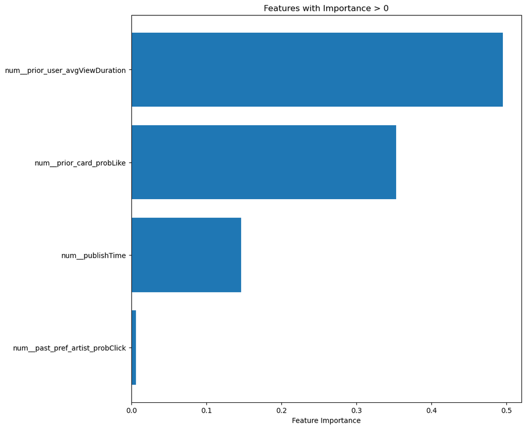

```python
# Set the max depth for the tree
max_depth = 3

tree = DecisionTreeClassifier(random_state=0, max_depth = max_depth, criterion='entropy', class_weight='balanced')

# Fit decision tree on the training data
tree.fit(X_train, y_train)

# Get feature importances
feature_importances = tree.feature_importances_

# Create a dictionary to associate feature names with importances
feature_importance_dict = dict(zip(feature_names, feature_importances))

# Round feature importances to 3 decimal places
rounded_importances = {feature: round(importance, 3) for feature, importance in feature_importance_dict.items()}

# Get features with importance greater than 0
positive_importances = {feature: importance for feature, importance in rounded_importances.items() if importance > 0}

# Sort positive importances
sorted_positive_importances = sorted(positive_importances.items(), key=lambda x: x[1], reverse=False)

# Plot the positive feature importances
plt.figure(figsize=(10, 10))
plt.barh(range(len(sorted_positive_importances)), [importance for _, importance in sorted_positive_importances], align='center')
plt.yticks(range(len(sorted_positive_importances)), [feature for feature, _ in sorted_positive_importances])
plt.xlabel('Feature Importance')
plt.title('Features with Importance > 0')
plt.show()
```

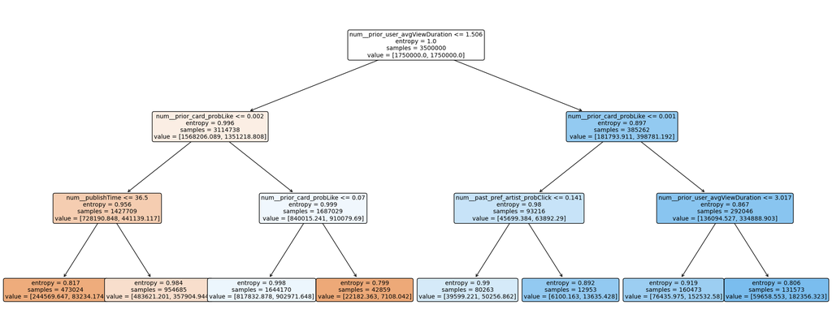

```python
# Plot the tree
plt.figure(figsize=(25, 10))
plot_tree(tree, feature_names=feature_names, filled=True, rounded=True, fontsize=10)
plt.show()
```

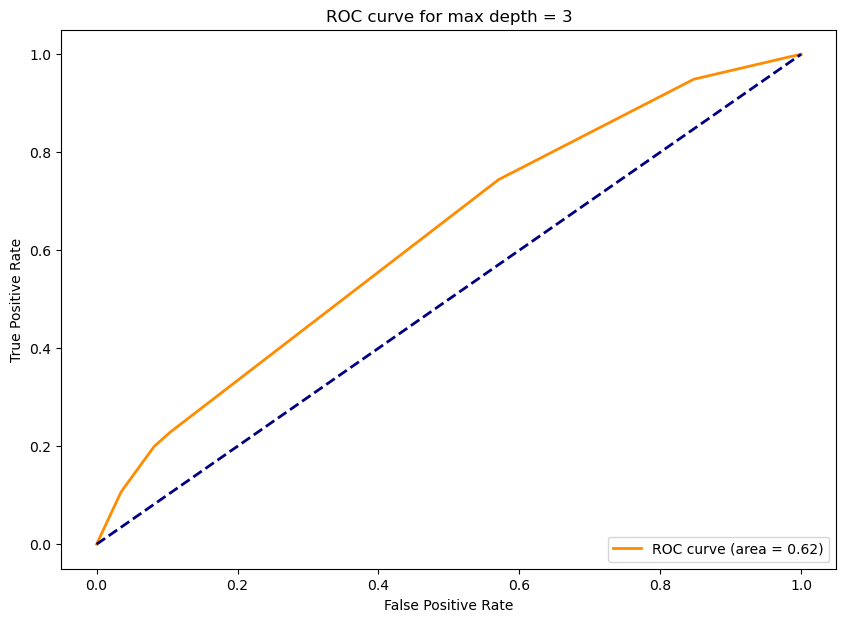

```
The accuracy of the model is 0.445018
```

```python
# Calculate the y_scores
y_pred_prob = tree.predict_proba(X_test)[:, 1]

# Calculate ROC curve
roc_auc_curve(y_pred_prob, f"ROC curve for max depth = {max_depth}")

# Print the accuracy of the simple tree
print(f"The accuracy of the model is {accuracy_score(y_test, tree.predict(X_test))}")
```

The simple tree model is able to give a ROC that is above the threshhold of .5. The ROC value is not far from the fully tuned logistic regression model, but the accuracy is quite low still, which is expected for such a simplistic model.

The next step is to use cross validation to test different hyper-parameter combinations. For that, we select trees with increasing maximum depths, changing criterion and minimum sample splits. The best paramaters are then used in the main modelling notebook.

```
Best Parameters:  {'min_samples_split': 200, 'max_depth': 5, 'criterion': 'entropy'}
```

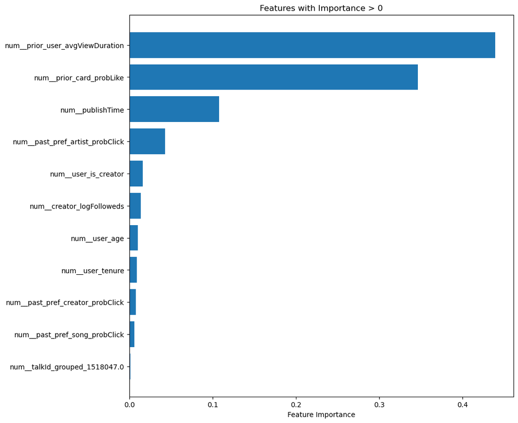

```python
# Define the hyperparameter grid

param_grid = {
    'max_depth': np.arange(5, 30, 5),  # Adjust the range based on your problem
    'criterion': ['gini', 'entropy'],
    'min_samples_split' : [50,100,200,500]
}


# Create a DecisionTreeClassifier
tree = DecisionTreeClassifier(random_state=0)

# Make scorer
auc_scorer = make_scorer(roc_auc_score)

# Create a RandomizedSearchCV object
random_search = RandomizedSearchCV(tree, param_distributions=param_grid,
                                   n_iter=8, cv=4, scoring=auc_scorer, random_state=0)

# Fit the RandomizedSearchCV object to the data
random_search.fit(X_train, y_train)

# Print the best parameters found by RandomizedSearchCV
print("Best Parameters: ", random_search.best_params_)

# Get the best DecisionTreeClassifier model
best_tree = random_search.best_estimator_

# Fit the best model on the training data
best_tree.fit(X_train, y_train)

# Get feature importances
feature_importances = best_tree.feature_importances_

# Create a dictionary to associate feature names with importances
feature_importance_dict = dict(zip(feature_names, feature_importances))

# Round feature importances to 3 decimal places
rounded_importances = {feature: round(importance, 3) for feature, importance in feature_importance_dict.items()}

# Get features with importance greater than 0
positive_importances = {feature: importance for feature, importance in rounded_importances.items() if importance > 0}

# Sort positive importances
sorted_positive_importances = sorted(positive_importances.items(), key=lambda x: x[1], reverse=False)

# Plot the positive feature importances
plt.figure(figsize=(10, 10))
plt.barh(range(len(sorted_positive_importances)), [importance for _, importance in sorted_positive_importances], align='center')
plt.yticks(range(len(sorted_positive_importances)), [feature for feature, _ in sorted_positive_importances])
plt.xlabel('Feature Importance')
plt.title('Features with Importance > 0')
plt.show()
```